# 1a. Initialize OSM data

This notebook:

- Loads the polygon defining the study area and then creates a grid overlay for the study area.
- Downloads street network data for the study area using OSMnx.
- Creates a network only with bicycle infrastructure (with queries defined in `config.yml`).
- Creates additional attributes in the data to be used in the analysis.

**Sections**

- Load data for study area and create analysis grid
- Download and preprocess OSM data

## Load data for study area and create analysis grid

This step:

- Loads settings for the analysis from the configuration file `config.yml`.
- Reads data for the study area.
- Creates a grid overlay of the study area, with grid cell size as defined in `config.yml`.

### Load data for study area

The study area is defined by the user-provided polygon. It will be used for the computation of **global** results, i.e. quality metrics based on all data in the study area.

```
The size of the study area is 388.59 km2.
```

### Create analysis grid

```
The grid contains 6614 square cells with a side length of 250 m and an area of 0.06 km2.
This grid will be used for local (grid cell level) analysis:
```

[figure not shown]

## Download and preprocess OSM data

This step:

- Downloads data from OpenStreetMap using OSMnx.
- Projects the data to the chosen CRS.
- Creates a subnetwork consisting only of bicycle infrastructure.
- Classifies all edges in the bicycle network based on whether they are protected or unprotected bicycle infrastructure, how they have been digitized, and whether they allow for bidirectional travel or not.
- Simplifies the network.
- Creates copies of all edge and node data sets indexed by their intersecting grid cell.

**OSM data model**

In OSM, street network data are stored using *nodes* (points) and *ways* (lines). In BikeDNA, OSM data are converted to a network structure consisting of *nodes* and *edges* (we use the terminology used in OSMnx). Edges represents the actual infrastructure, such as bike lanes and paths, while nodes represents the start and end points for the edges, as well as all intersections. For further details, read more about the [OSM data model](https://alga.win.tue.nl/tutorials/openstreetmap/) and the [network data model](https://networkx.org/documentation/stable/reference/introduction.html).

```
No update necessary. Returning original bicycle graph.
Edges where 'bicycle_bidirectional' is False: 8255 out of 8479 (97.36%)
Edges where 'bicycle_bidirectional' is True: 224 out of 8479 (2.64%)


Edges where the geometry type is 'true_geometries': 7782 out of 8479 (91.78%)
Edges where the geometry type is 'centerline': 697 out of 8479 (8.22%)


Edges where the protection level is 'protected': 6581 out of 8479 (77.62%)
Edges where the protection level is 'mixed': 1201 out of 8479 (14.16%)
Edges where the protection level is 'unprotected': 697 out of 8479 (8.22%)
```

[figure not shown]

```
The network covers an area of 110.76 km2.
The length of the OSM network with bicycle infrastructure is 112.41 km.
```

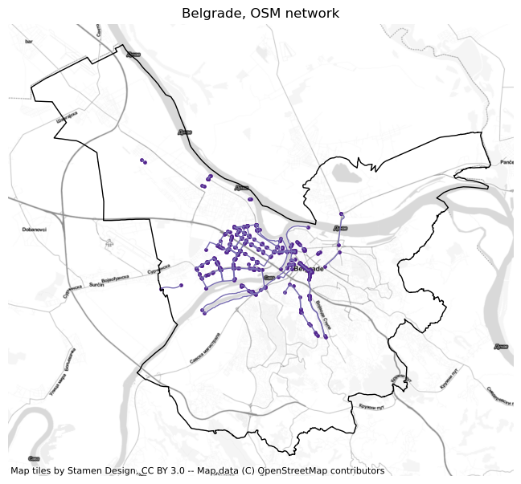